# Closed Testing Procedure

Paul Jordan

2021-04-27

# The Closure Principle

The closure principle is a way to protect the type-I error from multiple testing. Here, we follow the description in (Bretz, Hothorn, T., and Westfall, P. 2011). It consists of four steps:

1. Definition of a set ${H} = \{H_1,\ldots, H_n\}$ of elementary hypotheses.
2. Construction of the closure set (“Hypothesis Tree”).

$$\overline{H} = \left \{ H_I =\bigcap_{i \in I}H_i : \quad I \subseteq \{1,\ldots,n\} \right \}$$
$$(\text{all intersection hypotheses} H_I ).$$

3. Construction of a local level-$\alpha$ test for each $H_I \in \overline{H}$.
4. Rejection of $H_i$, if *all* null hypotheses $H_I \in \overline{H}$ with $i \in I$ are rejected at at the local level $\alpha$.

## Adjusted p-values

As the null hypothesis $H_i$ is rejected only if the null hypotheses $H_I \in \overline{H}$ with $i \in I$ are rejected (see point 4. above), the adjusted p-value $p_{adj;i}$ for $H_i$ is defined as:

1. Denote with $p_I$ the p-value for a given intersection hypothesis $H_I, \quad I \subseteq \{1, \ldots,n\}$.
2. Then, $p_{adj;i}=\max_\limits{I:i\in I} p_I,\quad i=1,\ldots , n$.

# Implementation

The package was designed in partcular for treatment comparisons in ANOVA-like situations.

## Closure set

The hypothesis tree of the closed testing procedure is created using the function `IntersectHypotheses`.

## Local tests for a given “hypothesis tree”

In the case of single hypotheses (i.e. if the hypothesis can be described by a single integer vector e.g. **(1,3,5)** the test (F-Test, Kruskal-Wallis-test, probability test, logrank test, ….) is applied directly.

For combined hypotheses (i.e. for hypotheses described by several non-overlapping integer vectors eg. **(1,2), (3,4)**, The procedure differs for (generalised) linear hypotheses and other tests.

In the case of generalised linear hypotheses, the contrast matrices for the single hypotheses included are combined and these contrasts are tested simultaneously. Henceforth, functions from the package `emmeans`(Russell and Lenth 2020) are used, as for all othe linear and generalised linear hypotheses. For all other tests, first the p-values $p_1, p_2, \ldots ,p_m$ for the single hypotheses are calculated, and then these are combined by Fisher’s combination rule:

If all $m$ hypotheses are assumed to be independent, the test statistics $X$ follows under $H_0$ a $\chi^2$-distribution with $2m$ degrees of freedom:
$$X=-2\sum_{i=1}^{m}\ln(p_i) \sim \chi_{2m}^2$$
from which a p-value for the global hypothesis can be easily obtained.

In the case of trend tests, the same type of test is applied for all intermediate single tests.

## Adjusted p-values

Finally the p-values for the elementary *hypotheses* are adjusted by calculating the maximum of the p-values from the hypotheses in the *testing set* of the respective hypothesis.

The function `AnalyseCTP` calculates all local p-values and the adjusted p-values for all *elementary* hypotheses.

With the function `Adjust_raw`, it is also possible to use p-values that have been calculated by other functions or software to calculate the adjusted p-values.

## Testing set for a specific elementary hypothesis

The testing set for a specific elementary hyothesis can be printed by the function `TestingSet`.

```r
library(CTP)
        Pairwise <- IntersectHypotheses(list(c(1,2), c(1,3),
                                        c(1,4), c(2,3), c(2,4), c(3,4)))
    Set24    <- TestingSet(Pairwise,"[24]")
    Set24
```

```
## [1] "[24]"     "[124]"    "[13][24]" "[234]"    "[1234]"
```

## Comparing means

The dataframe `pasi` comprises the changes in PASI-score (Psoriasis Area and Severity Index) from baseline within two month in 72 patients treated with three different doses of Etretin or Placebo in a double blind study.

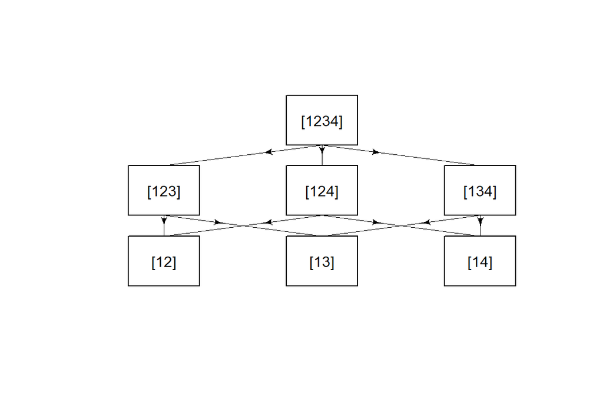

```r
library(CTP)

data(pasi)
three.to.first <- IntersectHypotheses(list(1:2,c(1,3),c(1,4)))
Display(three.to.first,Type="s",arrow=TRUE)
```

```r
pasi.ctp.F1    <- AnalyseCTP(three.to.first,pasi.ch~dose,pasi)

summary(pasi.ctp.F1)
```

```
##
## Summary of Closed Testing Procedure
## ===================================
##
## Model : pasi.ch ~ dose , test : F
##
## Factor levels: 1=Placebo, 2=ET.10mg, 3=ET.25mg, 4=ET.50mg
##
## Elementary Hypotheses and p-values
## ----------------------------------
##
##  Hypothesis raw p-value adj. p-value
##        [12]   4.748e-03    4.748e-03
##        [13]   2.737e-05    1.063e-04
##        [14]   1.826e-06    9.797e-06
```

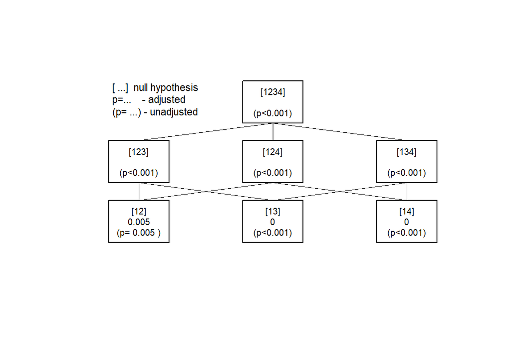

```r
Display(pasi.ctp.F1)
```

## Another hypothesis structure

Testing the elementary hypotheses 1:2, 2:3, 3:4 simultaneously using the F-Test, i.e. testing $H_1: \mu_1=\mu_2$, $H_2: \mu_2=\mu_3$ and $H_3: \mu_3=\mu_4$ simultaneously. This provides quite different results (compared to `pasi.ctp.F1`): No further improvement for higher doses.

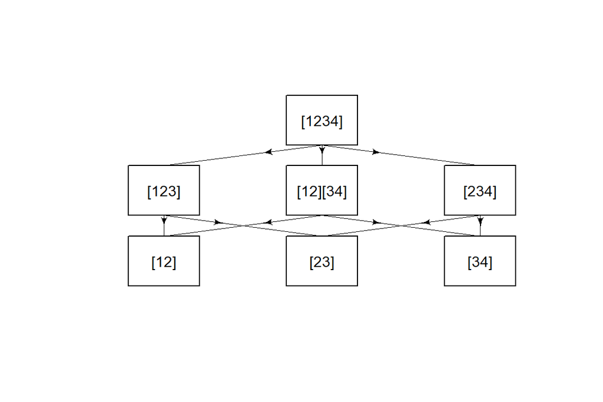

```r
dose.steps4 <- IntersectHypotheses(list(1:2,2:3,3:4))
Display(dose.steps4,arr=TRUE)
```

```r
pasi.ctp.F2 <- AnalyseCTP(dose.steps4,pasi.ch~dose,pasi)
summary(pasi.ctp.F2)
```

```
##
## Summary of Closed Testing Procedure
## ===================================
##
## Model : pasi.ch ~ dose , test : F
##
## Factor levels: 1=Placebo, 2=ET.10mg, 3=ET.25mg, 4=ET.50mg
##
## Elementary Hypotheses and p-values
## ----------------------------------
##
##  Hypothesis raw p-value adj. p-value
##        [12]    0.004748      0.01506
##        [23]    0.113879      0.11388
##        [34]    0.525687      0.52569
```

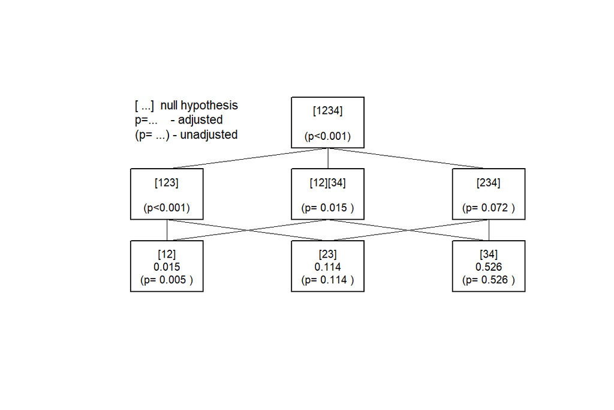

```r
Display(pasi.ctp.F2)
```

## Other tests

For the same hypothesis structure, other tests can also be used:

### Generalized Linear Models

As an example, a positive response is defined as a change from baseline PASI score greater than 50. The new variable `Resp` has then the value 1 if *pasi.ch > 50* or 0 otherwise. The corresponding model is chosen to be a generalised linear model with logit-link, as implemented in `glm`.

```r
pasi$Resp <- ifelse(pasi$pasi.ch > 50,1,0)

pasi.ctp_bin <-AnalyseCTP(three.to.first,Resp~dose,pasi,test.name="glm",family="binomial")
summary(pasi.ctp_bin)
```

```
##
## Summary of Closed Testing Procedure
## ===================================
##
## Model : Resp ~ dose , test : glm
##
## Test options:  family : binomial
##
## Factor levels: 1=Placebo, 2=ET.10mg, 3=ET.25mg, 4=ET.50mg
##
## Elementary Hypotheses and p-values
## ----------------------------------
##
##  Hypothesis raw p-value adj. p-value
##        [12]    0.036876     0.036876
##        [13]    0.001952     0.005163
##        [14]    0.001577     0.003370
```

### Kruskal-Wallis test of trend for all single hypotheses

```r
pasi.ctp.K <- AnalyseCTP(dose.steps4,pasi.ch~dose,pasi, test="kruskal")
summary(pasi.ctp.K)
```

```
##
## Summary of Closed Testing Procedure
## ===================================
##
## Model : pasi.ch ~ dose , test : kruskal
##
## Factor levels: 1=Placebo, 2=ET.10mg, 3=ET.25mg, 4=ET.50mg
##
## Elementary Hypotheses and p-values
## ----------------------------------
##
##  Hypothesis raw p-value adj. p-value
##        [12]      0.0235      0.05605
##        [23]      0.1655      0.16554
##        [34]      0.4255      0.42546
```

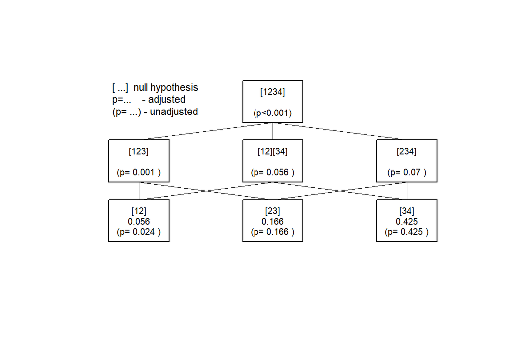

```r
Display(pasi.ctp.K)
```

### Jonckheere-Terpstra test of trend for all single hypotheses

```r
pasi.ctp.J1 <- AnalyseCTP(dose.steps4,pasi.ch~dose,pasi, test="jonckheere",alternative="increasing")
summary(pasi.ctp.J1)
```

```
##
## Summary of Closed Testing Procedure
## ===================================
##
## Model : pasi.ch ~ dose , test : jonckheere
##
## Test options:  alternative : increasing
##
## Factor levels: 1=Placebo, 2=ET.10mg, 3=ET.25mg, 4=ET.50mg
##
## Elementary Hypotheses and p-values
## ----------------------------------
##
##  Hypothesis raw p-value adj. p-value
##        [12]     0.01179      0.05652
##        [23]     0.08284      0.08284
##        [34]     0.21415      0.21415
```

## Proportions

The data set `colorectal` contains the response rates from a dose finding study in metastatic colorectal cancer. Two doses of the experimental drug were compared to the standard treatment. The response rates in the two dose groups are compared to the control responder rate using both, the $\chi^2$-test and Fisher’s exact test.

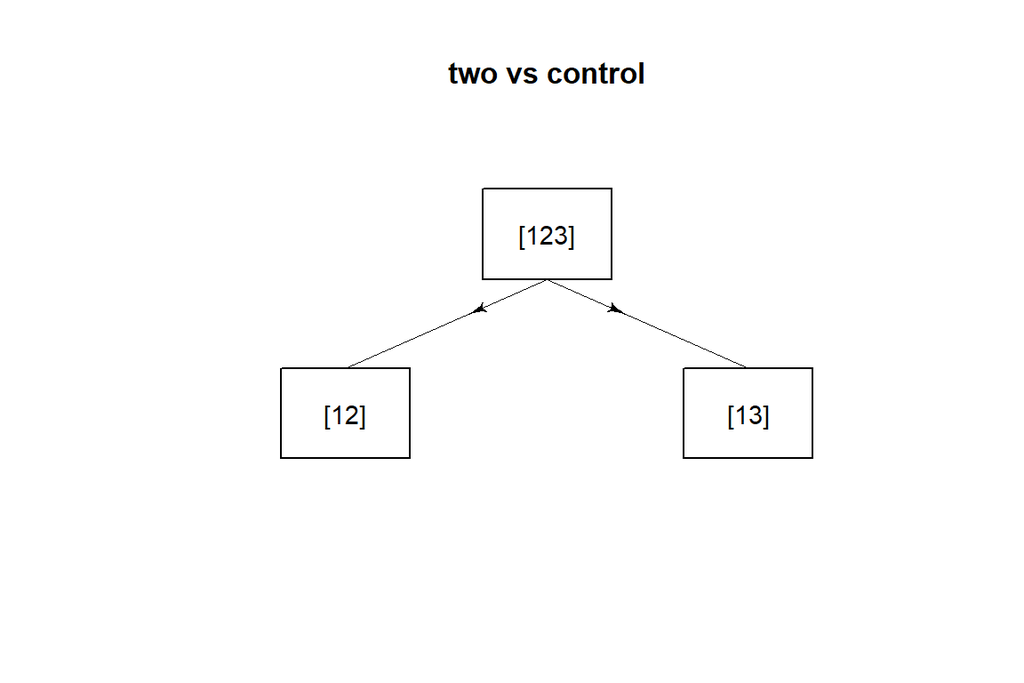

```r
two.to.first<- IntersectHypotheses(list(1:2,c(1,3)))

Display(two.to.first,Type="s",main="two vs control",arrow=TRUE)
```

```r
#The two elementary hypotheses  are tested after comparing the three proportions globally.

data(colorectal)
colorectal.ctp <-AnalyseCTP(two.to.first,responder~dose,data=colorectal, test="prob")
summary(colorectal.ctp)
```

```
##
## Summary of Closed Testing Procedure
## ===================================
##
## Model : responder ~ dose , test : prob
##
## Factor levels: 1=control, 2=low, 3=high
##
## Elementary Hypotheses and p-values
## ----------------------------------
##
##  Hypothesis raw p-value adj. p-value
##        [12]     0.02018      0.04459
##        [13]     0.09877      0.09877
```

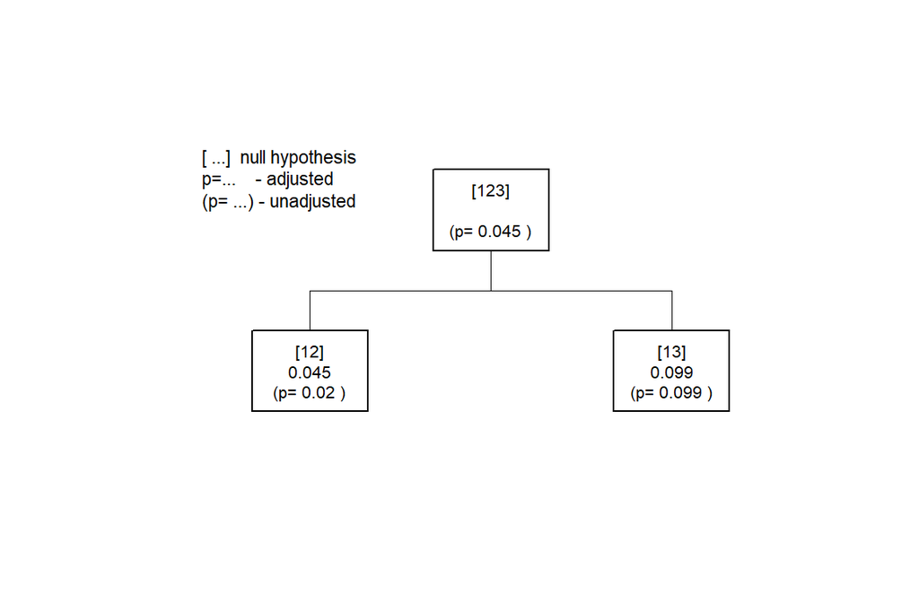

```r
Display(colorectal.ctp,Type="t")
```

```r
colorectal.chisq <-AnalyseCTP(two.to.first,responder~dose,data=colorectal, test="chisq")
summary(colorectal.chisq, digits=1)
```

```
##
## Summary of Closed Testing Procedure
## ===================================
##
## Model : responder ~ dose , test : chisq
##
## Factor levels: 1=control, 2=low, 3=high
##
## Elementary Hypotheses and p-values
## ----------------------------------
##
##  Hypothesis raw p-value adj. p-value
##        [12]        0.03         0.05
##        [13]        0.11         0.11
```

## Survival Analysis with the logrank test

This example uses the sample dataset `ovarian` from the package `survival`. The overall survival curves of the two treatments `rx` do not differ significantly:

```r
library(survival)
       data(ovarian)

       print(survdiff(Surv(futime,fustat)~rx, data=ovarian))
```

```
## Call:
## survdiff(formula = Surv(futime, fustat) ~ rx, data = ovarian)
##
##       N Observed Expected (O-E)^2/E (O-E)^2/V
## rx=1 13        7     5.23     0.596      1.06
## rx=2 13        5     6.77     0.461      1.06
##
##  Chisq= 1.1  on 1 degrees of freedom, p= 0.3
```

Together with the performance subgroups `ecog=1` and `ecog=2` , a factor “subgroups” defined by the combinations of the performance measure `ecog.ps` and the treatment `rx`.

```r
ovarian$subgroups <- as.factor(10*ovarian$ecog.ps+ovarian$rx)
print(head(ovarian))
```

```
##   futime fustat     age resid.ds rx ecog.ps subgroups
## 1     59      1 72.3315        2  1       1        11
## 2    115      1 74.4932        2  1       1        11
## 3    156      1 66.4658        2  1       2        21
## 4    421      0 53.3644        2  2       1        12
## 5    431      1 50.3397        2  1       1        11
## 6    448      0 56.4301        1  1       2        21
```

Then, the treatment differences within the performance subgroups ecog=1 and ecog=2 are compared. I.e. the elementary hypotheses are *subgroup11=subgroup12* and *subgroup21=subgroup22* or $\{(1,2),(3,4)\}$.

```r
comb.sub  <- IntersectHypotheses(list(c(1,2),c(3,4)))
#Display(comb.sub)
ovar.ctp  <-AnalyseCTP(comb.sub,Surv(futime,fustat)~subgroups, ovarian, test="lgrank")
summary(ovar.ctp)
```

```
##
## Summary of Closed Testing Procedure
## ===================================
##
## Model : Surv(futime, fustat) ~ subgroups , test : lgrank
##
## Factor levels: 1=11, 2=12, 3=21, 4=22
##
## Elementary Hypotheses and p-values
## ----------------------------------
##
##  Hypothesis raw p-value adj. p-value
##        [12]      0.1119       0.3171
##        [34]      0.8434       0.8434
```

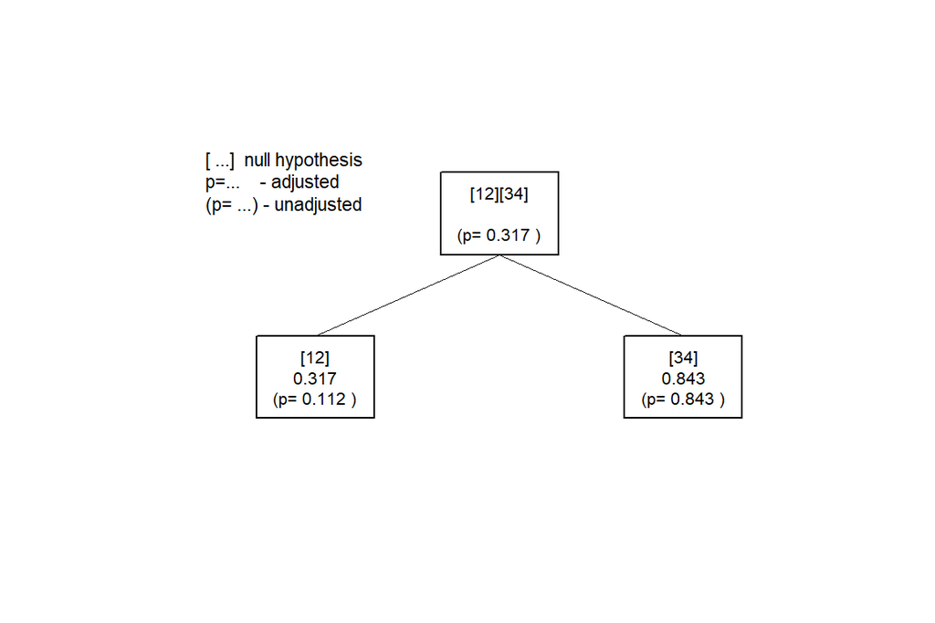

```r
Display(ovar.ctp)
```

## Comparing means when a covariate is included

In a study with diabetes type II patients (dataset `glucose`), three doses of a drug are compared to a placebo. The primary variable is the change of fasting plasma glucose from baseline. Fasting plasma glucose at baseline is included into the model as covariate (only implemented for linear and generalised linear models).

```r
data(glucose)
glucose.ctp <- AnalyseCTP(three.to.first,GLUCOSE.CHANGE~GLUCOSE.BLA+DOSE,
                         data=glucose, factor.name="DOSE")
summary(glucose.ctp)
```

```
##
## Summary of Closed Testing Procedure
## ===================================
##
## Model : GLUCOSE.CHANGE ~ GLUCOSE.BLA + DOSE , test : F
##
## Factor levels: 1=PLACEBO, 2=LOW, 3=MEDIUM, 4=HIGH
##
## Elementary Hypotheses and p-values
## ----------------------------------
##
##  Hypothesis raw p-value adj. p-value
##        [12]   6.033e-02    0.0603256
##        [13]   7.086e-05    0.0003536
##        [14]   6.917e-05    0.0003464
```

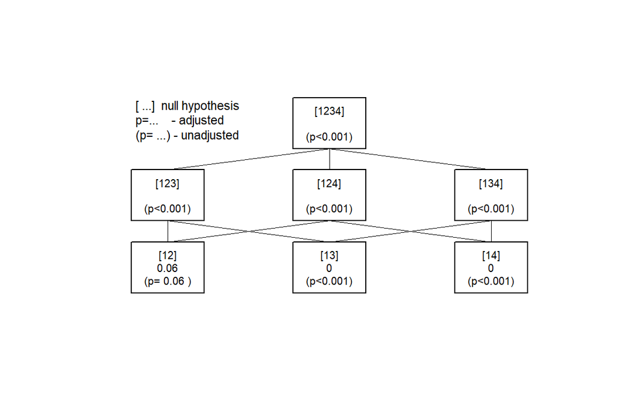

```r
Display(glucose.ctp,Type="s")
```

## Large hypothesis trees

Whith an increasing number of hypotheses to test, the graphical display may become quite confusing:

```r
G <- factor(rep(1:5,each=4) )
y <- rnorm(20)
Y <- data.frame(G,y)

xxx <- IntersectHypotheses(list(1:2,c(1,3),c(1,4),c(1,5),c(2,5),c(3,4)))
summary(xxx)
```

```
##
## Hypotheses to be tested
## =======================
##
##  hyp.no level hypothesis.name
##       1     1            [12]
##       2     1            [13]
##       3     1            [14]
##       4     1            [15]
##       5     1            [25]
##       6     1            [34]
##       1     2           [123]
##       2     2           [124]
##       3     2           [125]
##       4     2        [12][34]
```

[output cut: 86 more lines]

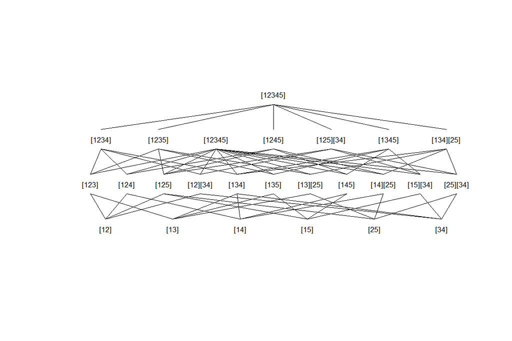

```r
Display(xxx)
```

## “External” p-values

It is possible to:

- Use `IntersectHypotheses` to create the closure set and `Display` to plot the corresponding hypothesis tree.
- Calculate the p-values for the local hypotheses with other functions or software.
- Import these p-values.
- Use `Adjust_raw` to calculte the adjusted p-values for the elementary hypotheses. `Adjust_raw` delivers an object of class `ctp`.
- Use `summary` and `Display` on this object.

```r
        Pairwise <- IntersectHypotheses(list(c(1,2), c(1,3), c(1,4), c(2,3), c(2,4), c(3,4)))
        Display(Pairwise)
```

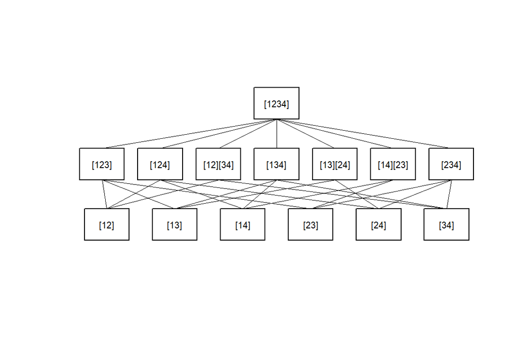

```r
        summary(Pairwise)
```

```
##
## Hypotheses to be tested
## =======================
##
##  hyp.no level hypothesis.name
##       1     1            [12]
##       2     1            [13]
##       3     1            [14]
##       4     1            [23]
##       5     1            [24]
##       6     1            [34]
##       1     2           [123]
##       2     2           [124]
##       3     2        [12][34]
##       4     2           [134]
```

[output cut: 34 more lines]

```r
        # the vector of p-values calculated by another software
        # (Example from Prof. John M. Lachin, The Biostatistics Center Rockville MD)

        p.val <- c(
          0.4374,
          0.6485,
          0.4103,
          0.2203,
          0.1302,
          0.6725,
          0.4704,
          0.3173,
          0.6762,
          0.7112,
          0.2866,
          0.3362,
          0.2871,
          0.4633)

        result <- Adjust_raw(Pairwise, p.value=p.val)

        summary(result,digits=3)
```

```
##
## Summary of Closed Testing Procedure
## ===================================
##
## Elementary Hypotheses and p-values
## ----------------------------------
##
##  Hypothesis raw p-value adj. p-value
##        [12]       0.437        0.676
##        [13]       0.648        0.711
##        [14]       0.410        0.711
##        [23]       0.220        0.470
##        [24]       0.130        0.463
##        [34]       0.672        0.711
```

```r
# details may be documented

        result <- Adjust_raw(Pairwise, p.value=p.val
                             ,dataset.name="my Data", factor.name="Factor"
                             ,factor.levels=c("A","B","C","D"), model=y~Factor
                             ,test.name="my Test")

        summary(result,digits=3)
```

```
##
## Summary of Closed Testing Procedure
## ===================================
##
## Model : y ~ Factor , test : my Test
##
## Factor levels: 1=A, 2=B, 3=C, 4=D
##
## Elementary Hypotheses and p-values
## ----------------------------------
##
##  Hypothesis raw p-value adj. p-value
##        [12]       0.437        0.676
##        [13]       0.648        0.711
##        [14]       0.410        0.711
##        [23]       0.220        0.470
##        [24]       0.130        0.463
##        [34]       0.672        0.711
```

## References

Bauer, Peter. 1991. “Multiple Testing in Clinical Trials.” *Statistics in Medicine* 10 (4): 261–63.

Bretz, Frank, Hothorn, T., and Westfall, P. 2011. *Multiple Comparisons Using R*. CRC Press.

Dmitrienko, Alex, Tamhane, A., and Bretz, F. 2010. *Multiple Testing Problems in Pharmaceutical Statistics*. Chapman & Hall.

Marcus, Ruth, Peritz, E., and Gabriel, K.R. 1976. “On Closed Testing Procedures with Special Reference to Ordered Analysis of Variance.” *Biometrika* 63: 655–60.

Russell, and Lenth. 2020. “Estimated Marginal Means, Aka Least-Squares Means.”